# 🛍️ Retail Sales Analysis & Forecasting

## 🔁 Check for Duplicate Rows

Duplicate rows can skew analysis results and inflate metrics like total sales.  
The code below counts how many duplicate rows are present in the dataset using `df.duplicated().sum()`.

```python
# Remove duplicates if
df.drop_duplicates(inplace=True)
print(df.duplicated().sum())
```

```
0
```

## 🧹 Convert Date Columns & Sort

To prepare the dataset for time series analysis and ensure chronological accuracy,  
we convert the `Order Date` and `Ship Date` columns to datetime format using `pd.to_datetime()` with `dayfirst=True` (since the date format is DD/MM/YYYY).

We also sort the dataset by `Order Date` to maintain proper time sequence before any trend or forecasting analysis.

The first few rows of the cleaned data are displayed below, along with a summary of the dataset.

```python
# Convert date columns with dayfirst format
df["Order Date"] = pd.to_datetime(df["Order Date"], dayfirst=True)
df["Ship Date"] = pd.to_datetime(df["Ship Date"], dayfirst=True)

# Sort by Order Date
df.sort_values("Order Date", inplace=True)


print("✅ Cleaned data preview:")
print(df.head())
print("\n🔍 Dataset info:")
print(df.info())
```

```
✅ Cleaned data preview:
      `Row ID        Order ID Order Date  Ship Date       Ship Mode  \
7980     7981  CA-2015-103800 2015-01-03 2015-01-07  Standard Class
741       742  CA-2015-112326 2015-01-04 2015-01-08  Standard Class
740       741  CA-2015-112326 2015-01-04 2015-01-08  Standard Class
739       740  CA-2015-112326 2015-01-04 2015-01-08  Standard Class
1759     1760  CA-2015-141817 2015-01-05 2015-01-12  Standard Class

     Customer ID  Customer Name      Segment        Country          City  \
7980    DP-13000  Darren Powers     Consumer  United States       Houston
741     PO-19195  Phillina Ober  Home Office  United States    Naperville
740     PO-19195  Phillina Ober  Home Office  United States    Naperville
739     PO-19195  Phillina Ober  Home Office  United States    Naperville
1759    MB-18085     Mick Brown     Consumer  United States  Philadelphia

             State  Postal Code   Region       Product ID         Category  \
7980         Texas      77095.0  Central  OFF-PA-10000174  Office Supplies
741       Illinois      60540.0  Central  OFF-BI-10004094  Office Supplies
740       Illinois      60540.0  Central  OFF-ST-10002743  Office Supplies
739       Illinois      60540.0  Central  OFF-LA-10003223  Office Supplies
1759  Pennsylvania      19143.0     East  OFF-AR-10003478  Office Supplies

     Sub-Category                                       Product Name    Sales
7980        Paper  Message Book, Wirebound, Four 5 1/2" X 4" Form...   16.448
741       Binders         GBC Standard Plastic Binding Systems Combs    3.540
740       Storage                      SAFCO Boltless Steel Shelving  272.736
739        Labels                                          Avery 508   11.784
1759          Art  Avery Hi-Liter EverBold Pen Style Fluorescent ...   19.536

🔍 Dataset info:
<class 'pandas.core.frame.DataFrame'>
Index: 9800 entries, 7980 to 5091
Data columns (total 18 columns):
 #   Column         Non-Null Count  Dtype
---  ------         --------------  -----
 0   `Row ID        9800 non-null   int64
 1   Order ID       9800 non-null   object
 2   Order Date     9800 non-null   datetime64[ns]
 3   Ship Date      9800 non-null   datetime64[ns]
 4   Ship Mode      9800 non-null   object
 5   Customer ID    9800 non-null   object
 6   Customer Name  9800 non-null   object
 7   Segment        9800 non-null   object
 8   Country        9800 non-null   object
 9   City           9800 non-null   object
 10  State          9800 non-null   object
 11  Postal Code    9800 non-null   float64
 12  Region         9800 non-null   object
 13  Product ID     9800 non-null   object
 14  Category       9800 non-null   object
 15  Sub-Category   9800 non-null   object
 16  Product Name   9800 non-null   object
 17  Sales          9800 non-null   float64
dtypes: datetime64[ns](2), float64(2), int64(1), object(13)
memory usage: 1.4+ MB
None
```

## 🧾 Inspect Column Names

To get an overview of all column names in the dataset, we use `df.columns.tolist()`.  
This helps identify any unwanted spaces, special characters, or naming inconsistencies before proceeding with renaming or cleaning.

```python
print(df.columns.tolist())
```

```
['`Row ID', 'Order ID', 'Order Date', 'Ship Date', 'Ship Mode', 'Customer ID', 'Customer Name', 'Segment', 'Country', 'City', 'State', 'Postal Code', 'Region', 'Product ID', 'Category', 'Sub-Category', 'Product Name', 'Sales']
```

## 📈 Monthly Sales Trend

To analyze overall sales performance over time, we group the data by month using the `Order Date` column.  
We convert it to a Period (Year-Month) format, aggregate total sales for each period, and plot the results.

This trend visualization helps identify:

- High-performing months
- Seasonal patterns
- Overall business growth

The chart below shows the monthly sales trend throughout the dataset's timeline.

```
✅ 'Sales' in columns: True
```

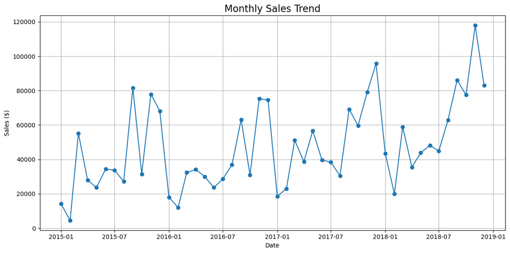

```python
# Load your data (use the correct path)
df = pd.read_csv("/Users/mohamedhelill/Downloads/train.csv")

df["Order Date"] = pd.to_datetime(df["Order Date"], dayfirst=True)
df["Ship Date"] = pd.to_datetime(df["Ship Date"], dayfirst=True)

df.columns = df.columns.str.strip()

# Confirm column exists
print("✅ 'Sales' in columns:", "Sales" in df.columns)

# Fix date format
df["Order Date"] = pd.to_datetime(df["Order Date"], dayfirst=True)

# Group by Year-Month
monthly_sales = df.groupby(df["Order Date"].dt.to_period("M"))["Sales"].sum()

# Convert index to datetime
monthly_sales.index = monthly_sales.index.to_timestamp()

# Plot
plt.figure(figsize=(12, 6))
plt.plot(monthly_sales.index, monthly_sales.values, marker='o')
plt.title("Monthly Sales Trend", fontsize=16)
plt.xlabel("Date")
plt.ylabel("Sales ($)")
plt.grid(True)
plt.tight_layout()
plt.show()
```

## 📦 Sales by Product Category

This chart summarizes the total sales across the three main product categories: Furniture, Office Supplies, and Technology.  
By grouping the dataset by `Category` and summing the sales values, we can easily identify which category contributes the most to revenue.

This insight helps business stakeholders prioritize inventory, promotions, and marketing efforts for the highest-performing categories.

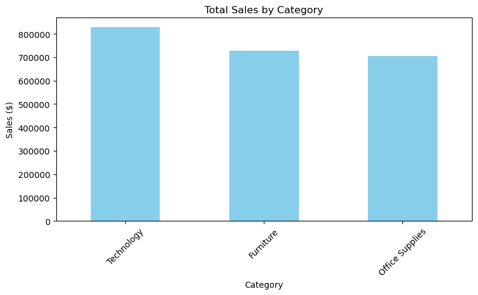

```python
category_sales = df.groupby("Category")["Sales"].sum().sort_values(ascending=False)

plt.figure(figsize=(8, 5))
category_sales.plot(kind='bar', color='skyblue')
plt.title("Total Sales by Category")
plt.ylabel("Sales ($)")
plt.xticks(rotation=45)
plt.tight_layout()
plt.show()
```

## 🧾 Sales by Sub-Category

This horizontal bar chart breaks down total sales by each product **sub-category**.  
By grouping the data on the `Sub-Category` column, we can pinpoint which specific product lines are performing well and which may need more attention or improvement.

This level of granularity helps stakeholders:

- Optimize product offerings
- Identify low-performing sub-categories
- Allocate resources based on product performance

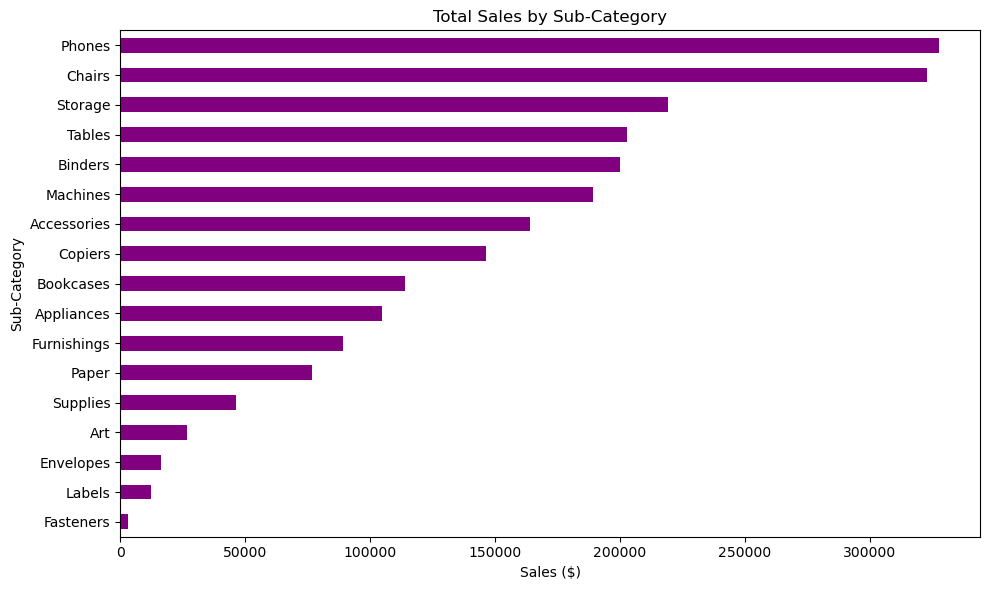

```python
subcategory_sales = df.groupby("Sub-Category")["Sales"].sum().sort_values()

plt.figure(figsize=(10, 6))
subcategory_sales.plot(kind='barh', color='purple')
plt.title("Total Sales by Sub-Category")
plt.xlabel("Sales ($)")
plt.tight_layout()
plt.show()
```

## 🌍 Sales by Region

This bar chart illustrates total sales grouped by `Region`.  
It provides a clear comparison of revenue performance across different geographical areas (Central, East, South, West).

Understanding regional performance helps the business:

- Identify strong and weak markets
- Focus marketing and sales efforts regionally
- Make informed expansion or investment decisions

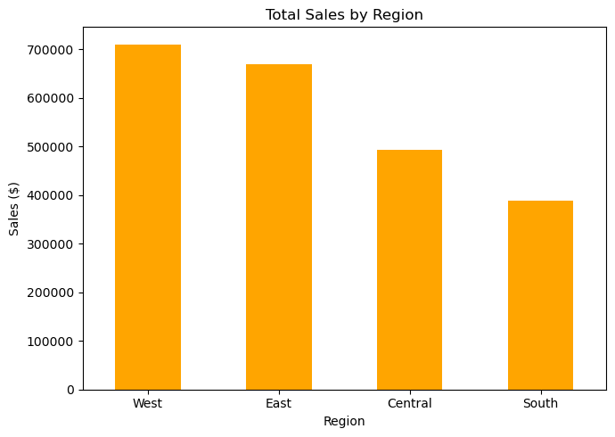

```python
region_sales = df.groupby("Region")["Sales"].sum().sort_values(ascending=False)

plt.figure(figsize=(7, 5))
region_sales.plot(kind='bar', color='orange')
plt.title("Total Sales by Region")
plt.ylabel("Sales ($)")
plt.xticks(rotation=0)
plt.tight_layout()
plt.show()
```

## 👤 Sales by Customer Segment

This chart shows the total sales grouped by `Segment`, revealing which customer types drive the most revenue:

- **Consumer**
- **Corporate**
- **Home Office**

Understanding segment performance allows businesses to:

- Tailor marketing strategies to high-value customer groups
- Adjust pricing or product offerings by segment
- Discover new growth opportunities by targeting underperforming segments

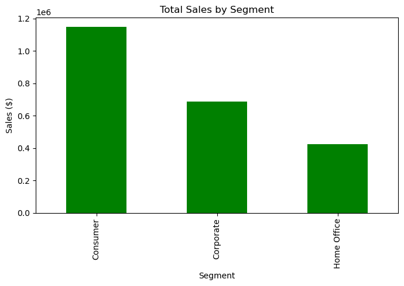

```python
segment_sales = df.groupby("Segment")["Sales"].sum().sort_values(ascending=False)

plt.figure(figsize=(7, 5))
segment_sales.plot(kind='bar', color='green')
plt.title("Total Sales by Segment")
plt.ylabel("Sales ($)")
plt.tight_layout()
plt.show()
```

```python
# Total_Sales = df["Sales"].sum()
# print("🧾 Total Sales: $", round(Total_Sales, 2))
```

```python
# Total_Sales = df["Sales"].sum()
# display(Markdown(f"### 💰 **Total Sales:** ${Total_Sales:,.2f}"))
```

## 🧮 Retail Performance Summary (KPIs)

These figures help stakeholders understand:

- Overall sales volume
- Customer reach
- Product diversity
- Sales activity scale

```python
# Total Number of Orders
total_orders = df["Order ID"].nunique()

# Unique Products Sold
unique_products = df["Product ID"].nunique()

# Total Customers
total_customers = df["Customer ID"].nunique()

# Display as Markdown for clean formatting
display(Markdown(f"""
## 📊 Retail Performance Summary

- 💰 **Total Sales:** ${Total_Sales:,.2f}
- 🛒 **Total Orders:** {total_orders:,}
- 📦 **Unique Products Sold:** {unique_products:,}
- 👤 **Total Customers:** {total_customers:,}
"""))
```

📊 Retail Performance Summary

- 💰 **Total Sales:** $2,261,536.78

- 🛒 **Total Orders:** 4,922

- 📦 **Unique Products Sold:** 1,861

- 👤 **Total Customers:** 793

## 🏆 Top 10 Best-Selling Products

This chart displays the top 10 products based on total sales.  
By grouping the dataset by `Product Name` and summing their sales values, we can identify the products that contribute the most to overall revenue.

These insights help:

- Recognize high-performing items for promotion or inventory prioritization
- Understand product-level demand
- Inform decisions around bundling, discounts, or discontinuation

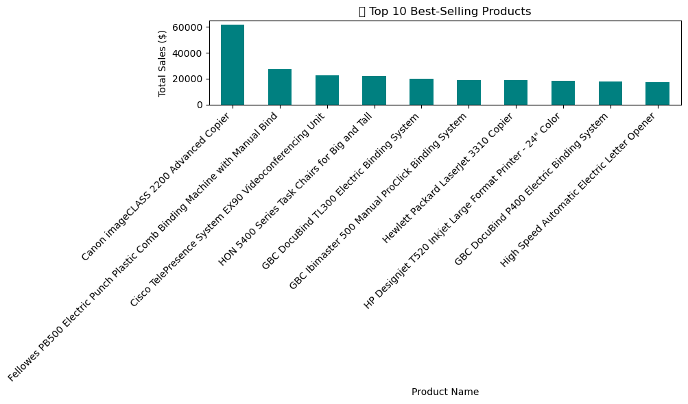

```python
# Group sales by product name
top_products = df.groupby("Product Name")["Sales"].sum().sort_values(ascending=False).head(10)

plt.figure(figsize=(10, 6))
top_products.plot(kind='bar', color='teal')
plt.title("🏆 Top 10 Best-Selling Products")
plt.ylabel("Total Sales ($)")
plt.xlabel("Product Name")
plt.xticks(rotation=45, ha='right')
plt.tight_layout()
plt.show()
```

## 🔮 Sales Forecasting with Facebook Prophet

To forecast future sales, we use **Facebook Prophet**, a powerful time series forecasting library designed for business applications.  
We aggregate daily sales and train the model on historical data. Prophet automatically detects trends and seasonality, making it ideal for retail sales data.

In this section:

- Sales are grouped by day and formatted for Prophet (`ds`, `y`)
- A model is trained on historical sales data
- Future dates (90 days ahead) are generated
- A forecast is produced and visualized

The resulting forecast provides valuable insight into expected sales trends for the upcoming quarter.

```
11:37:06 - cmdstanpy - INFO - Chain [1] start processing
11:37:06 - cmdstanpy - INFO - Chain [1] done processing
```

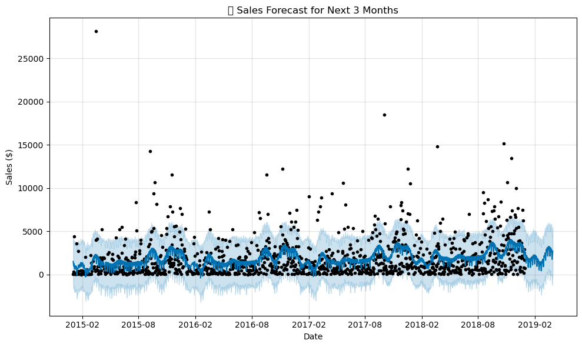

```python
# Aggregate daily sales
sales_daily = df.groupby("Order Date")["Sales"].sum().reset_index()

# Rename columns for Prophet
sales_daily.columns = ["ds", "y"]

# Initialize and fit the model
model = Prophet()
model.fit(sales_daily)

# Create future dataframe
future = model.make_future_dataframe(periods=90)

# Predict future sales
forecast = model.predict(future)


# Plot forecast
fig = model.plot(forecast)
plt.title("📈 Sales Forecast for Next 3 Months")
plt.xlabel("Date")
plt.ylabel("Sales ($)")
plt.tight_layout()
plt.show()
```

## 📊 Forecast Components: Trend & Seasonality

These components help uncover hidden patterns that inform better inventory planning, marketing campaigns, and staffing strategies.

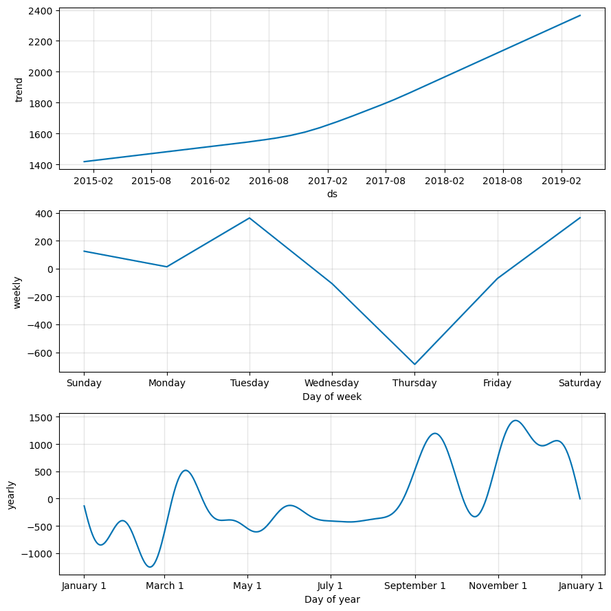

```python
# Plot trend & seasonality components
model.plot_components(forecast)
plt.tight_layout()
plt.show()
```

## 📤 Export Forecast Results to Excel

To share the forecast results with stakeholders or for further analysis in Excel or Power BI,  
we select the relevant forecast columns and export them to an `.xlsx` file.

The exported file includes:

- `ds`: Date
- `yhat`: Predicted sales
- `yhat_lower` and `yhat_upper`: Confidence interval bounds

This allows easy integration of forecasts into business reports, dashboards, or presentations.

```python
# Select useful forecast columns
forecast_result = forecast[["ds", "yhat", "yhat_lower", "yhat_upper"]]

# Export to Excel
forecast_result.to_excel("sales_forecast.xlsx", index=False)

print("✅ Forecast exported to 'sales_forecast.xlsx'")
```

```
✅ Forecast exported to 'sales_forecast.xlsx'
```

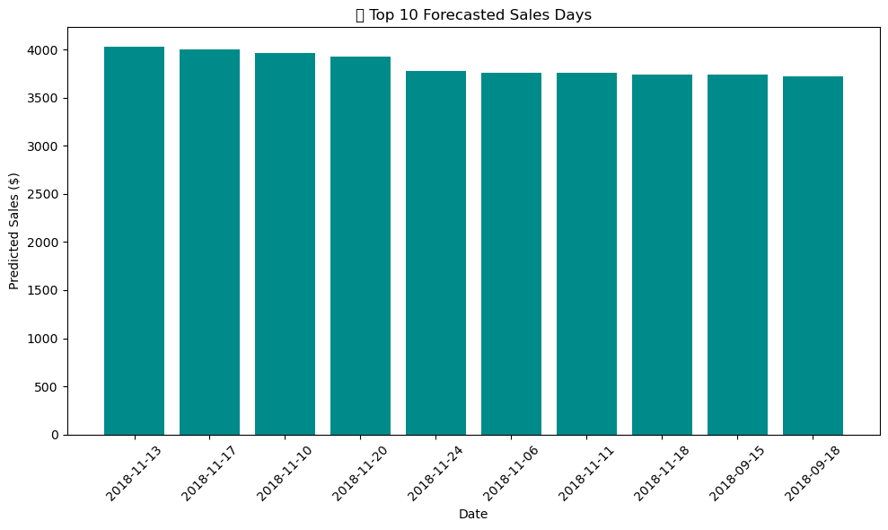

```python
# Get top 10 future dates by forecasted sales
top_forecast = forecast_result.sort_values(by="yhat", ascending=False).head(10)

# Plot
plt.figure(figsize=(10, 6))
plt.bar(top_forecast["ds"].dt.strftime("%Y-%m-%d"), top_forecast["yhat"], color='darkcyan')
plt.title("🔝 Top 10 Forecasted Sales Days")
plt.xlabel("Date")
plt.ylabel("Predicted Sales ($)")
plt.xticks(rotation=45)
plt.tight_layout()
plt.show()
```

# 📊 Retail Sales Analysis and Forecasting Report

## ✅ Final Conclusion

The **Retail Sales Analysis and Forecasting** project provided a comprehensive overview of sales performance over time. Through Exploratory Data Analysis (EDA), trend evaluation, and time series forecasting using Prophet, the project successfully identified key sales patterns and projected future trends.

The analysis uncovered notable seasonality and demand fluctuations influenced by time of year and possibly promotional events. These findings are instrumental in guiding strategic planning, inventory management, and marketing activities. The forecasted sales for the next three months provide valuable insight for short-term decision-making and resource allocation.

## 🛠️ Strategic Recommendations

1. **Establish a Data Management Process**
   - Ensure real-time or daily updates to the sales database.
   - Assign a dedicated database manager to monitor data integrity and completeness.
2. **Leverage Seasonality for Marketing**
   - Launch campaigns aligned with peak demand months.
   - Introduce discounts, bundles, or loyalty rewards during off-peak periods to maintain steady sales.
3. **Enhance Forecasting Accuracy**
   - Integrate external factors such as holidays, weather, and economic trends to build more resilient models.
   - Continuously monitor model performance and update it with recent data.
4. **Adopt Business Intelligence Tools**
   - Use visualization tools like Power BI or Tableau for real-time sales monitoring.
   - Automate reporting workflows to support timely, data-driven decisions across departments.
5. **Segment Customers for Deeper Insights**
   - Analyze sales by customer segments to identify high-value clients and tailor offerings to their preferences.
   - Use segmentation insights for targeted campaigns and personalized promotions.
6. **Optimize Inventory Based on Forecasts**
   - Align procurement cycles with projected demand to minimize holding costs and lost sales.
   - Monitor fast-moving vs. slow-moving products and adjust stocking strategies accordingly.